# Introduction to Machine Learning with Scikit-Learn

Resources for Machine Learning

**Text**

- [Elements of Statistical Learning](http://statweb.stanford.edu/~tibs/ElemStatLearn/) \$71 (free PDF)
- [Introduction to Statistical Learning](http://www-bcf.usc.edu/~gareth/ISL/) \$54 (free PDF)
- [Learn from Data](http://www.amazon.com/gp/product/1600490069) \$28

**Online classes**

- [Stanford's Introduction to Statistical Learning](http://online.stanford.edu/course/statistical-learning-winter-2014)
- [Coursera's Machine Learning](https://www.coursera.org/course/ml)
- [Caltech's Learning from Data](http://work.caltech.edu/telecourse.html)

**Websites**

- [Kaggle](http://www.kaggle.com)
- [Metaoptimize](http://metaoptimize.com/)

**Online `sklearn` videos**

- [Jake Vanderplas'](http://www.astro.washington.edu/users/vanderplas/) excellent videos on Scikit-learn:
  - [PyData NYC 2013](https://vimeo.com/80093925) 1.5 hours
  - [Scipy 2013](http://pyvideo.org/video/2157/intro-to-scikit-learn-i-scipy2013-tutorial-pa-7) 8 hours.
  - [PyCon 2013](http://www.youtube.com/watch?v=4ONBVNm3isI) 3 hours.
  - [PyData NYC 2012](http://vimeo.com/53062607) 45 minutes.

## Outline

- Goal:
  - Introduction to `sklearn` API
  - Discuss basic ML concepts.
- What are some questions that `scikit learn` can address?
- Supervised Learning
- Model Selection
  - Cross validation
  - Bias-variance trade-off
  - Regularization
- Unsupervised learning
  - PCA
  - Clustering
- What we are not covering.

## Why `sklearn`?

- Consistent interface
- Great documentation
- More data $\rightarrow$ ML is more valuable
- Opportunity everywhere (almost)

```python
%matplotlib inline
import matplotlib.pyplot as plt
import numpy as np
try:
    import smash
    reload(smash)
except:
    pass
colors = plt.rcParams['axes.color_cycle']
```

## Machine Learning Questions

Let's look at this from a data perspective.

Input data:

- The $X$ matrix has $n$ samples and $m$ featues ($n , m$).
- We refer to $X$ as the **freatures**

Value to estimate:

- The $y$ vector has $n$ values ($n,$)
- Called the **response** vector.

### Boston Housing

```python
from sklearn import datasets
boston = datasets.load_boston()
X = boston.data
y = boston.target

print X.shape
print y.shape
```

```
(506, 13)
(506,)
```

```python
print boston.DESCR[165:1200]
```

```
    :Median Value (attribute 14) is usually the target

    :Attribute Information (in order):
        - CRIM     per capita crime rate by town
        - ZN       proportion of residential land zoned for lots over 25,000 sq.ft.
        - INDUS    proportion of non-retail business acres per town
        - CHAS     Charles River dummy variable (= 1 if tract bounds river; 0 otherwise)
        - NOX      nitric oxides concentration (parts per 10 million)
        - RM       average number of rooms per dwelling
        - AGE      proportion of owner-occupied units built prior to 1940
        - DIS      weighted distances to five Boston employment centres
        - RAD      index of accessibility to radial highways
        - TAX      full-value property-tax rate per $10,000
        - PTRATIO  pupil-teacher ratio by town
        - B        1000(Bk - 0.63)^2 where Bk is the proportion of blacks by town
        - LSTAT    % lower status of the population
        - MEDV     Median value of owner-occupied homes in $1000's
```

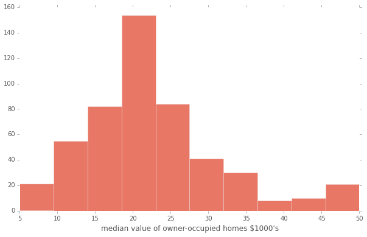

```python
plt.hist(y, alpha=0.75)
plt.xlabel("median value of owner-occupied homes $1000's")
plt.show()
```

Questions:

- Can we predict the median value of owner-occupied homes?
  - **regression**
- Which characteristics are most important when predicting home values?
  - **inference**, see `stats models`

### Handwritten Digits

```python
digits = datasets.load_digits()
X = digits.data
y = digits.target

print X.shape
print y.shape
```

```
(1797, 64)
(1797,)
```

```python
print digits.DESCR[:595]
```

```
 Optical Recognition of Handwritten Digits Data Set

Notes
-----
Data Set Characteristics:
    :Number of Instances: 5620
    :Number of Attributes: 64
    :Attribute Information: 8x8 image of integer pixels in the range 0..16.
    :Missing Attribute Values: None
    :Creator: E. Alpaydin (alpaydin '@' boun.edu.tr)
    :Date: July; 1998

This is a copy of the test set of the UCI ML hand-written digits datasets
http://archive.ics.uci.edu/ml/datasets/Optical+Recognition+of+Handwritten+Digits

The data set contains images of hand-written digits: 10 classes where
each class refers to a digit.
```

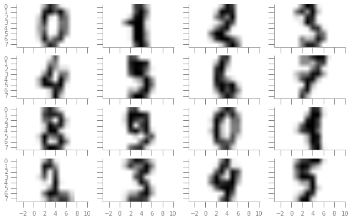

```python
fig, ax = plt.subplots(4,4, sharex=True, sharey=True)
for r in range(4):
    for c in range(4):
        ax[r,c].imshow(X[r*4+c].reshape(8,8), cmap=plt.cm.gray_r)
fig.show()
```

Questions:

- Given an image, can we correctly assign it to the correct numeric category?
  - **classification**
- Can we increase the performance (and accuracy) of our prediction by reducing the number of features?
  - **dimensionality reduction**

## Supervised and Unsupervised Learning

**Supervised**

- Given a set of labeled data.
- Goal: estimate $\hat{f}(X)$
- Predict
  - quantitative: Regression
  - qualitative: Classification

**Unsupervised Learning**

- We do not have labeled data.
- Clustering
- Dimensionality reduction

## The `estimator` object

Every algorithm in `sklearn` is an instance of the `estimator` class.

**Supervised methods**:

- `fit(X,y)`: given features $X$ and resonse $y$, estimate $\hat{f}(x)$.
- `predict(X)`: predict the value of $\hat{y}$ given $X$ (e.g. $\hat{f}(X)$).
- `score(X,y)`: Indication of fit.
- `model.predict_proba()`: for classification, returns a probability instead of class label.

**Usupervised methods**:

- `fit(X`): fit the training data.
- `transform(X)`: returns the new representation of $X$ based on the `fit`.

## Regression

- Linear Regression
- Nearest Neighbor Regression

```python
%matplotlib inline
import matplotlib.pyplot as plt
import numpy as np
try:
    import smash
    reload(smash)
except:
    pass
colors = plt.rcParams['axes.color_cycle']
```

```python
from sklearn.linear_model import LinearRegression
from sklearn.neighbors import KNeighborsRegressor

from sklearn.datasets.samples_generator import make_regression
```

```python
X, y = make_regression( n_samples=30, n_features=1, n_informative=1,
                        random_state=0, noise=75)
X = X + 5
y = y + 300

def plot():
    fig, ax = plt.subplots()
    ax.scatter(X[:,0], y, edgecolor='none', s=100, alpha=0.75, c=colors[0])
    ax.set_xlabel('X')
    ax.set_ylabel('y')
    fig.show()
```

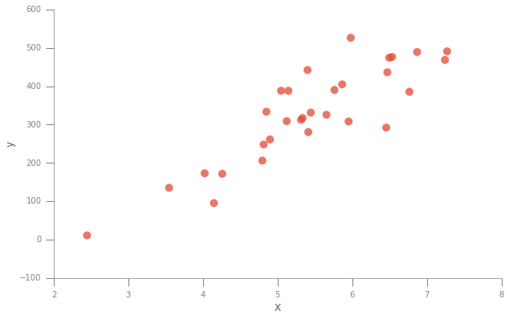

```python
plot()
```

### Linear Regression

```python
regr = LinearRegression()
regr.fit(X, y)

print regr.intercept_, regr.coef_
print regr.score(X,y)
```

```
-220.348130992 [ 100.96917215]
0.759670081702
```

```python
X_new = np.linspace(2,8,10)[:,np.newaxis] # to make it (n,m)
y_pred = regr.predict(X_new)
```

```python
def plot():
    fig, ax = plt.subplots()

    ax.plot(X_new[:,0], y_pred, color='darkgrey', linewidth=2)
    ax.scatter(X[:,0], y, edgecolor='none', s=100, alpha=0.75, c=colors[0])

    ax.set_xlabel('X')
    ax.set_ylabel('y')

    fig.show()
```

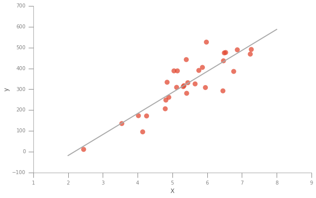

```python
plot()
```

### Nearst Neighbors

```python
regr_nn = KNeighborsRegressor()
regr_nn.fit(X, y)

print regr_nn.score(X,y)
```

```
0.781550018011
```

```python
def plot():
    fig, ax = plt.subplots()

    ax.scatter(X[:,0], y, edgecolor='none', s=100, alpha=0.75, c=colors[0])
    ax.plot(X_new[:,0], regr_nn.predict(X_new), color='darkgrey', linewidth=2)

    ax.set_xlabel('X')
    ax.set_ylabel('y')
    fig.show()
```

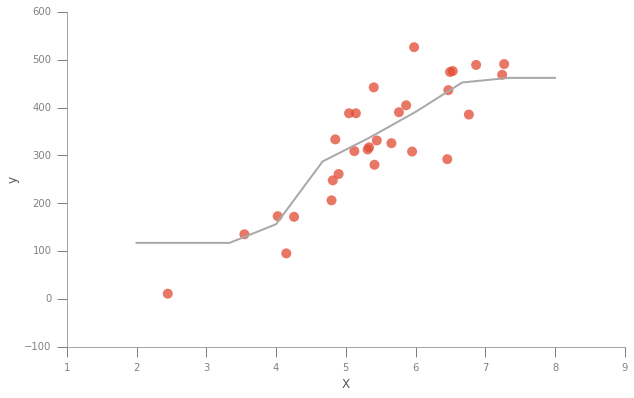

```python
plot()
```

### How do they Work?

```python
X, y = make_regression( n_samples=15, n_features=1, n_informative=1,
                        random_state=1, noise=35)
X = X + 5
y = y + 250
```

```python
regr.fit(X,y)
```

```
LinearRegression(copy_X=True, fit_intercept=True, normalize=False)
```

```python
def plot():
    fig, ax = plt.subplots()

    ax.vlines(X[:,0], regr.predict(X), y, color='grey')
    ax.scatter(X[:,0], y, edgecolor='none', s=100, alpha=1., c=colors[0])
    ax.plot(X_new[:,0], regr.predict(X_new) , color='darkgrey', linewidth=2)

    ax.set_xlabel('X')
    ax.set_ylabel('y')
    fig.show()
```

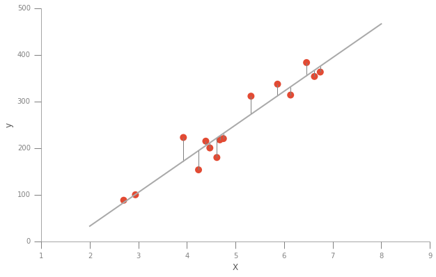

```python
plot()
```

```python
from sklearn import metrics

h = 50
xx, yy = np.meshgrid(np.linspace(0, regr.intercept_*2.0, h),
                     np.linspace(0, regr.coef_[0]*2.0, h))

Z = np.c_[xx.ravel(), yy.ravel()]
res = map(lambda z: metrics.mean_squared_error(y, z[0] + z[1]*X), Z)
res2 = np.array(res).reshape(xx.shape)

points = np.c_[ Z[np.argsort(res)[650]], np.array([regr.intercept_, regr.coef_[0]])].T
```

```python
def contour(ax):
    ax.contour(xx, yy, res2, 50, alpha=0.20, cmap=plt.cm.Greys_r)
    ax.contourf(xx, yy, res2, 50, alpha=0.20, cmap=plt.cm.Greys)
    ax.scatter(regr.intercept_, regr.coef_[0] , s=70,
               alpha=0.75, edgecolor='none', c=colors[0])
    ax.scatter(points[0][0], points[0][1], c=colors[1], s=70)

    ax.set_xlim(xx.min(), xx.max())
    ax.set_ylim(yy.min(), yy.max())

    ax.set_ylabel('coef_')
    ax.set_xlabel('intercept_')

def line(ax):
    ax.vlines(X[:,0], regr.predict(X), y, color='grey')
    ax.plot(X_new[:,0], points[0][0] + points[0][1]*X_new[:,0], color=colors[1])
    ax.plot(X_new[:,0], points[1][0] + points[1][1]*X_new[:,0], color=colors[0])
    ax.scatter(X[:,0], y, edgecolor='none', s=70, alpha=1., c=colors[0])

    ax.set_xlabel('X')
    ax.set_ylabel('y')

def plot():
    fig, ax = plt.subplots(1,2, figsize=(12,6))
    contour(ax[0])
    line(ax[1])
    fig.show()
```

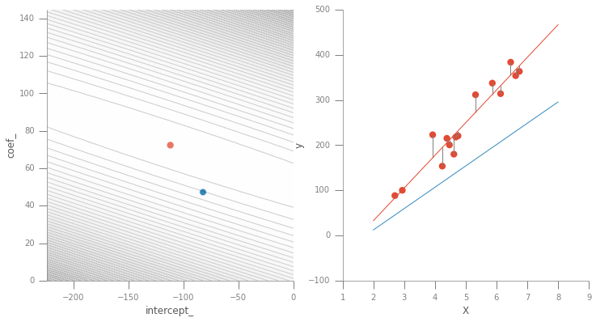

```python
plot()
```

```python
regr_nn.fit(X,y)
```

```
KNeighborsRegressor(algorithm='auto', leaf_size=30, metric='minkowski',
          n_neighbors=5, p=2, weights='uniform')
```

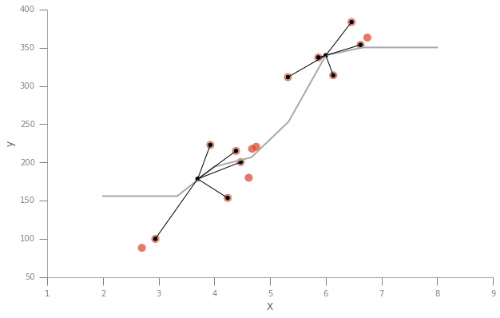

```python
fig, ax = plt.subplots()

ax.scatter(X[:,0], y, edgecolor='none', s=100, alpha=0.75, c=colors[0])
ax.plot(X_new[:,0], regr_nn.predict(X_new), color='darkgrey', linewidth=2)

pt = 3.7
neighbors = np.argsort(np.sqrt(np.square(X[:,0] - pt)))[:5]
for i in range(5):
    ax.plot( [ pt, X[neighbors[i]][0]] , [np.mean(y[neighbors]), y[neighbors[i]]], color='black' )
ax.scatter(X[neighbors], y[neighbors], c='black', s=40)
ax.scatter(pt, np.mean(y[neighbors]), c='black', s=40)

pt = 6
neighbors = np.argsort(np.sqrt(np.square(X[:,0] - pt)))[:5]
for i in range(5):
    ax.plot( [ pt, X[neighbors[i]][0]] , [np.mean(y[neighbors]), y[neighbors[i]]], color='black' )
ax.scatter(X[neighbors], y[neighbors], c='black', s=40)
ax.scatter(pt, np.mean(y[neighbors]), c='black', s=40)

ax.set_xlabel('X')
ax.set_ylabel('y')
fig.show()
```

## Classification

```python
from sklearn.neighbors import KNeighborsClassifier
from sklearn.linear_model import LogisticRegression

from sklearn.datasets.samples_generator import make_classification
from sklearn.datasets import make_circles
```

```python
def plotXY():
    fig, ax = plt.subplots()
    ax.scatter(X[:, 0], X[:, 1], c=y, s=70, alpha=0.75, edgecolor='none')
    ax.set_xlabel('X[:,0]')
    ax.set_ylabel('X[:,1]')
    fig.show()
```

```python
def plot(clf):
    h = 50
    x_min, x_max = X[:, 0].min() - .5, X[:, 0].max() + .5
    y_min, y_max = X[:, 1].min() - .5, X[:, 1].max() + .5
    xx, yy = np.meshgrid(np.linspace(x_min, x_max, h),
                         np.linspace(y_min, y_max, h))

    clf.fit(X, y)
    Z = clf.predict_proba(np.c_[xx.ravel(), yy.ravel()])[:, 1]
    Z = Z.reshape(xx.shape)

    fig, ax = plt.subplots()
    ax.contourf(xx, yy, Z, alpha=0.15, levels=[0,0.5,1], cmap=plt.cm.Greys)
    ax.scatter(X[:, 0], X[:, 1], c=y, s=70, alpha=0.75, edgecolor='none')
    ax.set_xlim(xx.min(), xx.max())
    ax.set_ylim(yy.min(), yy.max())
    ax.set_xlabel('X[:,0]')
    ax.set_ylabel('X[:,1]')
    fig.show()
```

### Madelon dataset

```python
X, y = make_classification(n_features=2, n_redundant=0, n_informative=2,
                           random_state=6, n_clusters_per_class=1)
```

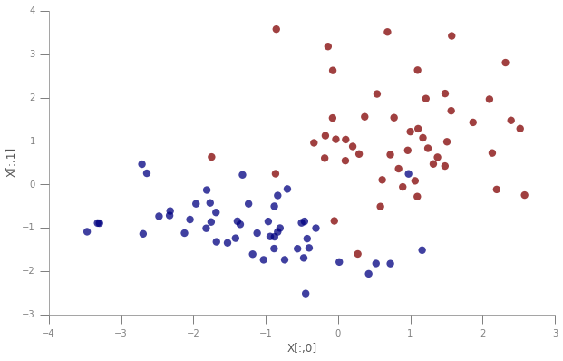

```python
plotXY()
```

```python
clf = KNeighborsClassifier()
clf.fit(X, y)
print clf.score(X,y)
```

```
0.95
```

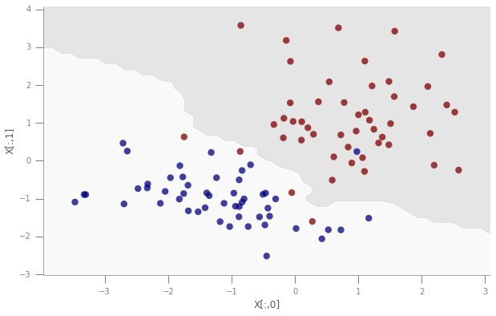

```python
plot(clf)
```

```python
clf = LogisticRegression()
clf.fit(X, y)
print clf.score(X,y)
```

```
0.95
```

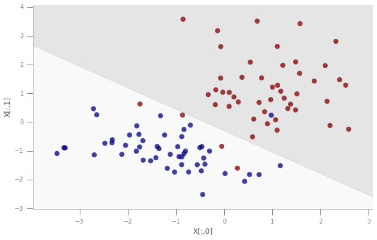

```python
plot(clf)
```

### Circles

```python
X, y = make_circles(noise=0.2, factor=0.5, random_state=1)
```

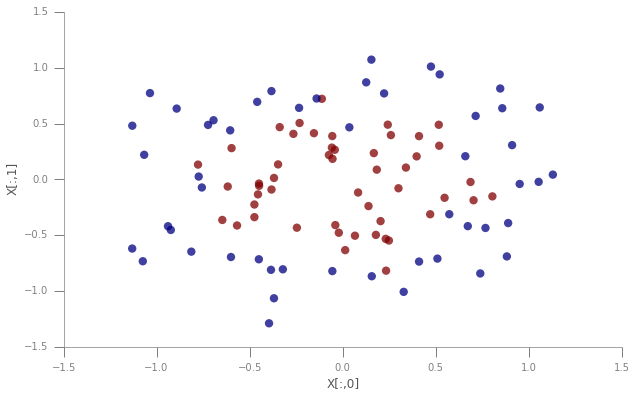

```python
plotXY()
```

```python
clf = KNeighborsClassifier()
clf.fit(X, y)
print clf.score(X,y)
```

```
0.9
```

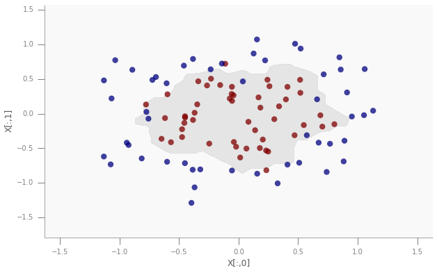

```python
plot(clf)
```

```python
clf = LogisticRegression()
clf.fit(X, y)
print clf.score(X,y)
```

```
0.48
```

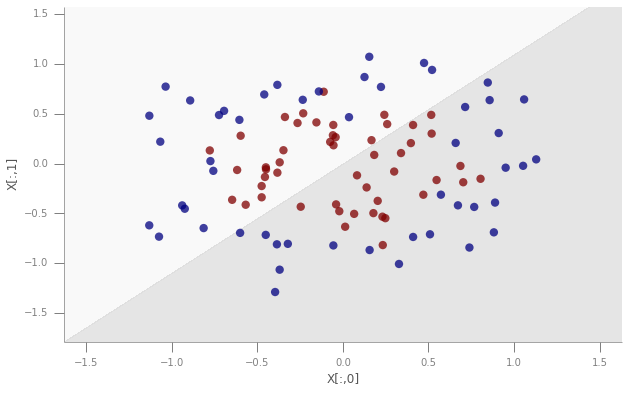

```python
plot(clf)
```

## Model Selection

- Cross validation
- Bias-Variance Trade-Off
- Regularization
  - Ridge
  - Lasso

```python
%matplotlib inline
import matplotlib.pyplot as plt
import numpy as np
try:
    import smash
    reload(smash)
except:
    pass
colors = plt.rcParams['axes.color_cycle']
```

```python
from sklearn import datasets
from sklearn.datasets.samples_generator import make_regression

from sklearn.neighbors import KNeighborsClassifier
from sklearn.neighbors import KNeighborsRegressor

from sklearn.linear_model import LogisticRegression
from sklearn.linear_model import LinearRegression
```

### Sample data

```python
X, y = make_regression( n_samples=60, n_features=1, n_informative=1,
                        random_state=0, noise=20)
X = X + 5
y = y + 300
```

```python
def plot():
    fig, ax = plt.subplots()
    ax.scatter(X[:,0], y, edgecolor='none', s=100, alpha=0.75, c=colors[0])
    ax.set_xlabel('X')
    ax.set_ylabel('y')
    fig.show()
```

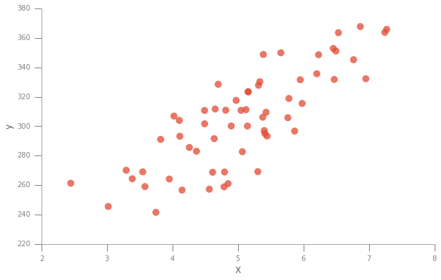

```python
plot()
```

```python
regr = LinearRegression()
regr.fit(X, y)
print regr.score(X,y)
```

```
0.659251562827
```

```python
regr_nn = KNeighborsRegressor(1)
regr_nn.fit(X, y)
print regr_nn.score(X,y)
```

```
1.0
```

### What's going on?

- `KNeighborsRegressor(1)`: we are just memorizing the data
- We are likely **overfitting** to the data.
  - Not likely to perform well on data we have not seen.
- Solution: **cross validate**

```python
def plot():
    fig, ax = plt.subplots()
    ax.scatter(X[:,0], y, edgecolor='none', s=100, alpha=0.75, c=colors[0])
    ax.plot(sorted(X[:,0]), regr_nn.predict(X[np.argsort(X[:,0])]), linewidth=2)
    ax.plot(X[:,0], regr.predict(X), linewidth=2)
    ax.set_xlabel('X')
    ax.set_ylabel('y')
    fig.show()
```

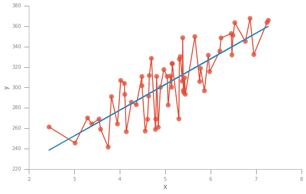

```python
plot()
```

### Cross Validation

```python
from sklearn import cross_validation

X, y = make_regression( n_samples=60, n_features=1, n_informative=1,
                        random_state=0, noise=10)
X = X + 5
y = y + 300

X_train, X_test, y_train, y_test = cross_validation.train_test_split(X, y,
                                        test_size=0.2, random_state=0)

print X.shape, X_train.shape, X_test.shape

def plot():
    fig, ax = plt.subplots()
    ax.scatter(X_train[:,0], y_train, edgecolor='none',
               s=100, alpha=0.5, c=colors[0], label='train')
    ax.scatter(X_test[:,0], y_test, edgecolor='none',
               s=100, alpha=1., c=colors[1], label='test')
    ax.set_xlabel('X')
    ax.set_ylabel('y')
    ax.legend(loc='upper left')
    fig.show()
```

```
(60, 1) (48, 1) (12, 1)
```

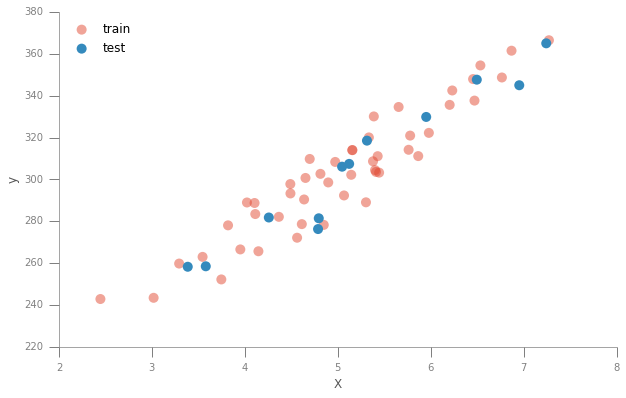

```python
plot()
```

```python
regr = LinearRegression()
regr.fit(X_train, y_train)
print regr.score(X_train, y_train)
print regr.score(X_test, y_test)
```

```
0.888219653513
0.939492295451
```

```python
regr_nn = KNeighborsRegressor(1)
regr_nn.fit(X_train, y_train)
print regr_nn.score(X_train, y_train)
print regr_nn.score(X_test, y_test)
```

```
1.0
0.809129476496
```

```python
regr_nn = KNeighborsRegressor(2)
regr_nn.fit(X_train, y_train)
print regr_nn.score(X_train, y_train)
print regr_nn.score(X_test, y_test)
```

```
0.937726017289
0.938673349488
```

```python
def plot():
    X = X_train
    y = y_train
    fig, ax = plt.subplots()
    ax.scatter(X_test[:,0], y_test, edgecolor='none',
               s=100, alpha=1, c=colors[1], label='test points')
    ax.plot(sorted(X[:,0]), regr_nn.predict(X[np.argsort(X[:,0])]),
            linewidth=2, label='KNeighborsRegressor(2)', color=colors[2])
    ax.plot(X[:,0], regr.predict(X), linewidth=2,
            label='LinearRegression()', color=colors[3])
    ax.set_xlabel('X')
    ax.set_ylabel('y')
    ax.legend(loc='upper left')
    fig.show()
```

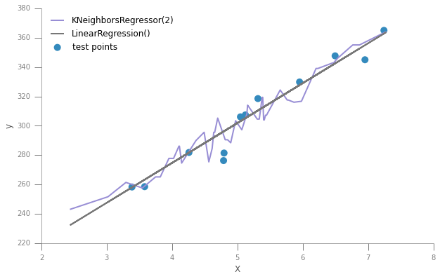

```python
plot()
```

### Bias-Variance Trade-Off

**Bias**

Refers to the error in our prediction that is introduced by our choice of model.

- e.g. Linear models assume a linear relationship

**Variance**

The amount our prediction will change if we use a different training set.

**Good predictions**

- will simultaneously minimize bias and variance.
- More flexible methods result in less bias.

### Trade-off?

Easy to find a low-bias method.

- `KNeighborsRegressor(1)` passes through every point.
- But... high variance when cross validated.

Easy to find a low-variance method.

- A hoizontal line.
- This has very high bias.

**Challange**: find a method that minimizes both

```python
from sklearn.metrics import mean_squared_error
from ipywidgets import StaticInteract, RangeWidget
```

Test function and `PolynomialRegression` taken from [Jake Vanderplas' excellent tutorial](http://nbviewer.ipython.org/github/jakevdp/2013_fall_ASTR599/blob/master/notebooks/18_IntermediateSklearn.ipynb).

```python
def test_func(x, err=0.5):
    y = 10 - 1. / (x + 0.1)
    if err > 0:
        y = np.random.normal(y, err)
    return y

def make_data(N=40, error=1.0, random_seed=1):
    # randomly sample the data
    np.random.seed(1)
    X = np.random.random(N)[:, np.newaxis]
    y = test_func(X.ravel(), error)

    return X, y
```

```python
class PolynomialRegression(LinearRegression):
    """Simple Polynomial Regression to 1D data"""
    def __init__(self, degree=1, **kwargs):
        self.degree = degree
        LinearRegression.__init__(self, **kwargs)

    def fit(self, X, y):
        if X.shape[1] != 1:
            raise ValueError("Only 1D data valid here")
        if self.degree > 1:
            Xp = X ** (1 + np.arange(self.degree))
            return LinearRegression.fit(self, Xp, y)
        else:
            return LinearRegression.fit(self, X, y)

    def predict(self, X):
        if self.degree > 1:
            Xp = X ** (1 + np.arange(self.degree))
            return LinearRegression.predict(self, Xp)
        else:
           return LinearRegression.predict(self, X)
```

```python
X_true, y_true = make_data(100, error=0.0)
X, y = make_data(100, error=1.0)
MSE = mean_squared_error(y, y_true)
print MSE
```

```
0.815400074255
```

```python
def plot():
    plt.scatter(X, y, c=colors[0], s=70, alpha=0.75)
    plt.plot(sorted(X_true[:,0]), y_true[np.argsort(X_true[:,0])],
         color="darkgrey", linewidth=2)
    plt.show()
```

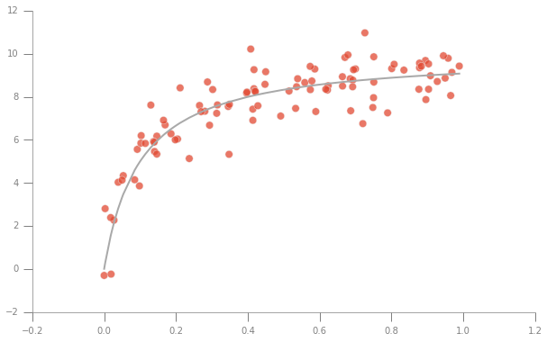

```python
plot()
```

```python
X_train, X_test, y_train, y_test = cross_validation.train_test_split(X, y,
                                        test_size=0.2, random_state=0)
test = []
train = []
shape = []
X_tmp = np.linspace(0,1,100)[:, np.newaxis]
```

```python
degree = range(1,20)
for d in degree:
    model = PolynomialRegression(degree=d)
    model.fit(X_train, y_train)
    test.append(mean_squared_error(model.predict(X_test), y_test))
    train.append(mean_squared_error(model.predict(X_train), y_train))
    shape.append(model.predict(X_tmp))
```

```python
def plot():
    plt.plot(np.array(degree)/20., test,'-')
    plt.plot(np.array(degree)/20., train,'-')
    plt.hlines(MSE, 0, 1)
    plt.xlabel('increasing flexibility')
    plt.ylabel('MSE')
    plt.show()
```

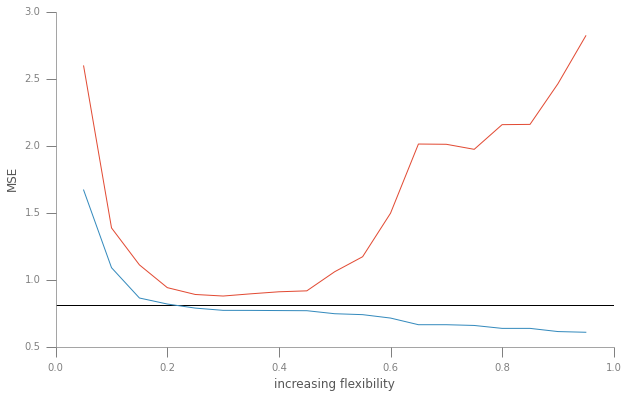

```python
plot()
```

```python
def plot(index):
    fig, ax = plt.subplots(1,2, figsize=(12,6))

    # Plot showing parameters
    ax[0].plot(np.array(degree)/20., test, linewidth=2, alpha=0.5)
    ax[0].plot(np.array(degree)/20., train,'-', linewidth=2, alpha=0.5)
    ax[0].hlines(MSE, 0, 1, label='MSE {0:0.1f}'.format(MSE))
    ax[0].scatter(degree[index]/20., test[index],
                  s=50, c=colors[0], label='test MSE {0:0.1f}'.format(test[index]))
    ax[0].scatter(degree[index]/20., train[index],
                  s=50, c=colors[1], label='train MSE {0:0.1f}'.format(train[index]))
    ax[0].set_xlabel('increasing flexibility')
    ax[0].set_ylabel('MSE')
    ax[0].set_xlim(0,1)
    ax[0].set_ylim(0.5,3.0)
    ax[0].legend(loc='upper center')

    ax[1].plot(X_tmp[:,0], shape[index], color='black', linewidth=2, label='fit')
    ax[1].scatter(X_train[:,0], y_train, alpha=0.5, c=colors[0], s=50, label='train')
    ax[1].scatter(X_test[:,0], y_test, alpha=0.5, c=colors[1], s=50, label='test')
    ax[1].set_ylim(-1,12)
    ax[1].set_xlabel('x')
    ax[1].set_ylabel('y')
    ax[1].legend(loc='lower right')

    return fig
```

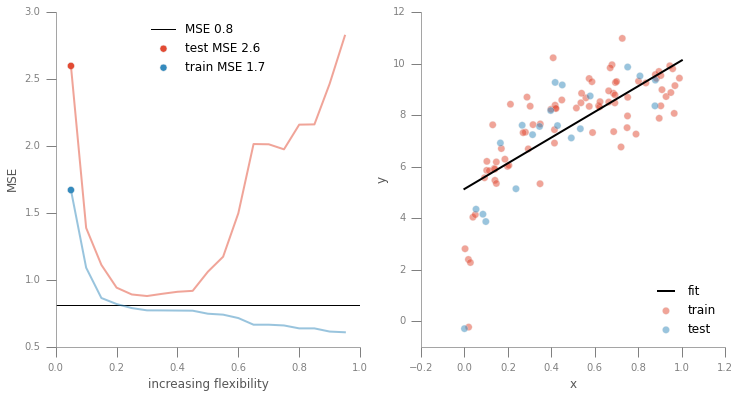

```python
StaticInteract(plot, index=RangeWidget(0,18))
```

## Regularization

```python
from sklearn.linear_model import Ridge
from sklearn.linear_model import Lasso
```

```python
samples = 100
features = 45
informative = 15
noise = 50

X, y = make_regression( n_samples=samples,
                        n_features=features,
                        n_informative=informative,
                        random_state=0,
                        noise=noise)

X_train, X_test, y_train, y_test = cross_validation.train_test_split(X, y,
                                            test_size=0.2, random_state=0)
```

```python
def plot_curves(alphas, train, test, coefs):

    fig, ax = plt.subplots(2,1, figsize=(10,8), sharex=True)

    ax[0].plot(alphas, train, label='train')
    ax[0].plot(alphas, test, label='test')
    ax[0].set_xscale('log')
    ax[0].set_ylabel('model.score()')
    ax[0].legend()

    ax[1].plot(alphas, coefs)
    ax[1].set_xscale('log')
    ax[1].set_xlabel('alpha value')
    ax[1].set_ylabel('model.coef_')
    ax[1].legend()

    fig.show()
```

```python
def plot_results(model):
    tests = []
    n_alphas = 200
    alphas = np.logspace(-2, 3, n_alphas)

    coefs = []
    train = []
    test = []
    for a in alphas:
        model.set_params(alpha=a)
        model.fit(X_train, y_train)
        coefs.append(model.coef_)
        test.append(model.score(X_test, y_test))
        train.append(model.score(X_train, y_train))

    plot_curves(alphas, train, test, coefs)
```

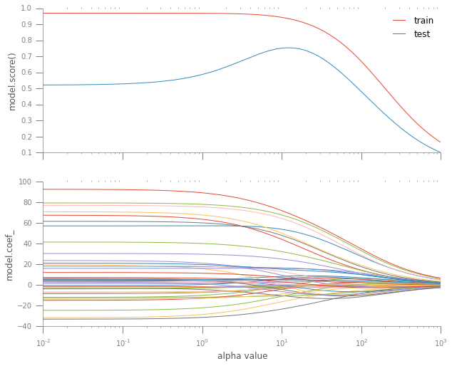

```python
model = Ridge()
plot_results(model)
```

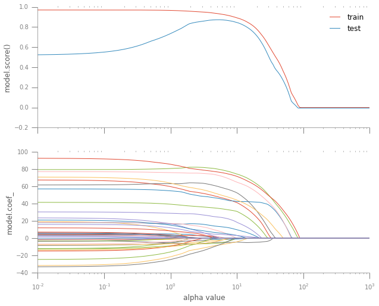

```python
model = Lasso()
plot_results(model)
```

```python
from sklearn.datasets import make_circles
from sklearn.neighbors import KNeighborsClassifier
```

```python
def plot_classify(index):

    clf = KNeighborsClassifier(index)
    clf.fit(X, y)
    h = 50
    x_min, x_max = X[:, 0].min() - .5, X[:, 0].max() + .5
    y_min, y_max = X[:, 1].min() - .5, X[:, 1].max() + .5
    xx, yy = np.meshgrid(np.linspace(x_min, x_max, h),
                         np.linspace(y_min, y_max, h))

    clf.fit(X, y)
    Z = clf.predict_proba(np.c_[xx.ravel(), yy.ravel()])[:, 1]
    Z = Z.reshape(xx.shape)

    fig, ax = plt.subplots()
    ax.contourf(xx, yy, Z, alpha=0.25, cmap=plt.cm.Greys)
    ax.scatter(X[:, 0], X[:, 1], c=y, s=70, alpha=0.75, edgecolor='none')
    ax.set_xlim(xx.min(), xx.max())
    ax.set_ylim(yy.min(), yy.max())
    ax.set_xlabel('X[:,0]')
    ax.set_ylabel('X[:,1]')

    return fig
```

```python
X, y = make_circles(noise=0.2, factor=0.5, random_state=1)
```

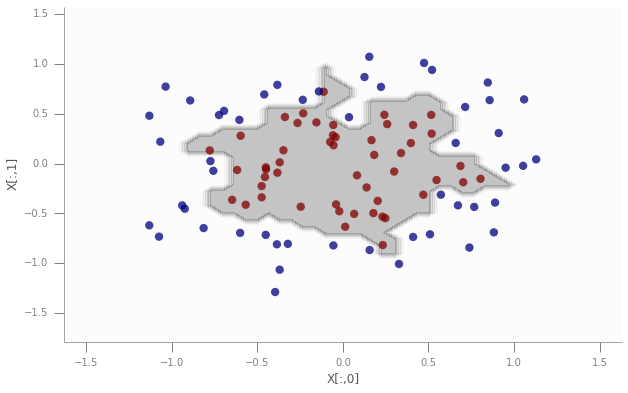

```python
StaticInteract(plot_classify, index=RangeWidget(1,20))
```

## Dimensionality Reduction with PCA

```python
%matplotlib inline
import matplotlib.pyplot as plt
import numpy as np

try:
    import smash
except:
    pass

from sklearn.datasets import load_digits
from sklearn.decomposition import PCA
from sklearn.preprocessing import scale
```

```python
digits = load_digits()
X = digits.data
y = digits.target
```

```python
print y[np.argsort(y)]
```

```
[0 0 0 ..., 9 9 9]
```

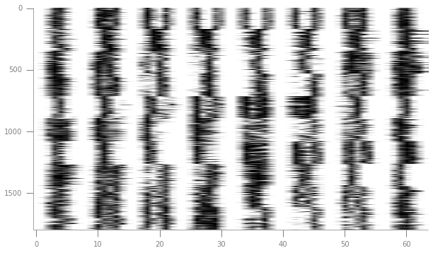

```python
plt.imshow(X[np.argsort(y),], aspect=0.02, cmap=plt.cm.gray_r)
plt.show()
```

```python
pca = PCA(n_components=64).fit(X)
X_reduced =pca.transform(X)
```

```python
print X_reduced.shape
```

```
(1797, 64)
```

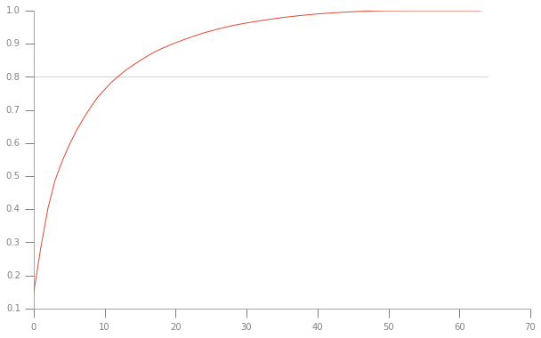

```python
plt.plot(pca.explained_variance_ratio_.cumsum())
plt.hlines(0.8, 0, 64, color='lightgrey')
plt.show()
```

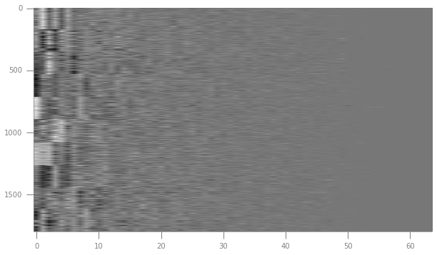

```python
plt.imshow(X_reduced[np.argsort(y),], aspect=0.02, cmap=plt.cm.gray_r)
plt.show()
```

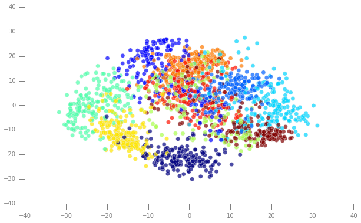

```python
plt.scatter(X_reduced[:,0], X_reduced[:,1], c=y, s=50, alpha=0.7)
plt.show()
```

## Clustering

```python
from sklearn.cluster import KMeans
from sklearn.datasets.samples_generator import make_classification
from sklearn.datasets import make_circles
```

```python
def plot_kmeans(X,y):
    y_pred = kmeans.fit(X).predict(X)
    fig, ax = plt.subplots(figsize=(6,6))

    ax.scatter(X[:, 0], X[:, 1], c=y, s=70,
               alpha=0.5, edgecolor='none')
    ax.scatter(X[y!=y_pred, 0], X[y!=y_pred, 1],c='black' , s=70,
               alpha=1.0, edgecolor='none')


    ax.set_xlabel('X[:,0]')
    ax.set_ylabel('X[:,1]')
    fig.show()
```

```python
kmeans = KMeans(init='k-means++', n_clusters=2, n_init=10)
```

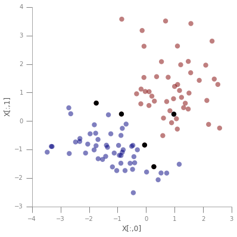

```python
X, y = make_classification(n_features=2, n_redundant=0, n_informative=2,
                           random_state=6, n_clusters_per_class=1)

y_pred = kmeans.fit(X).predict(X)
abs(y-y_pred)==0
plot_kmeans(X,y)
```

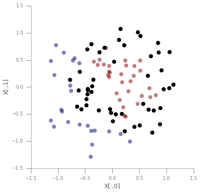

```python
X, y = make_circles(noise=0.2, factor=0.5, random_state=1)
plot_kmeans(X,y)
```

## Conclusion

- Data representation
- `Estimators`
  - LinearRegression
  - KNeighborsRegressor
  - LogisticRegression
  - KNeighborsClassifier
  - Ridge
  - Lasso
  - PCA
  - KMeans
- Bias-Variance Trade-off
  - Cross Validation

### Other Important Topics

- `metrics`
  - classification reports
  - confusion matrix
  - f1 score
  - ROC curves
  - ROC area
- Other `estimators`
  - SVM
  - Trees
  - and many more...
- Kfold CV
- Grid search, Random search
- Text methods
- Parallel execution